# Data Viz Part I

N.Paterno

## Quality Data Visualization

Being able to analyze data is a good quality. Being able to present it in a clear, concise format is even better. In part I of our data viz labs, we will focus expanding the graphs we made in lab 1 to be more clear, concise and have a bit more style.

First, lets draw our original histogram.

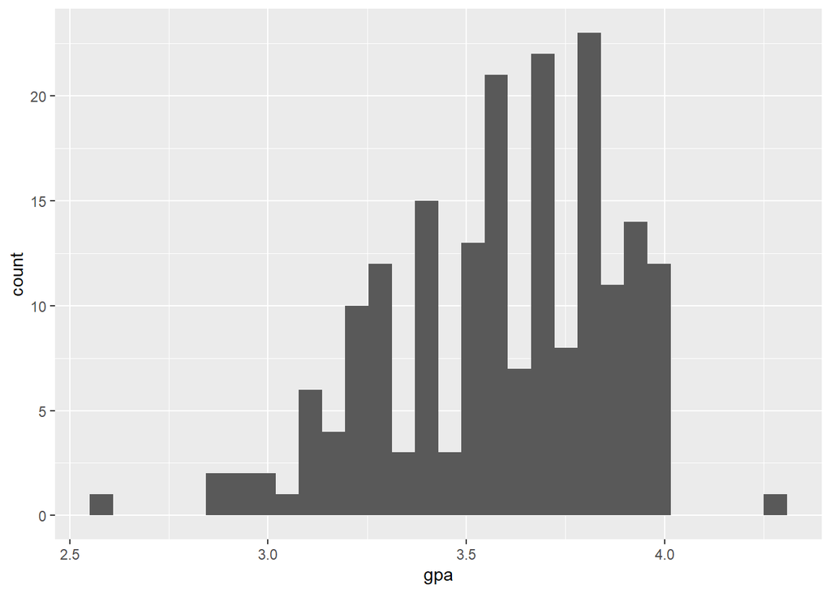

```r
ggplot(data = gpa_study_hours,
       aes(x = gpa))+
  geom_histogram()
```

Recall, we did make a few adjustments to this in lab 1; we changed the color of the border of the bars as well as their width.

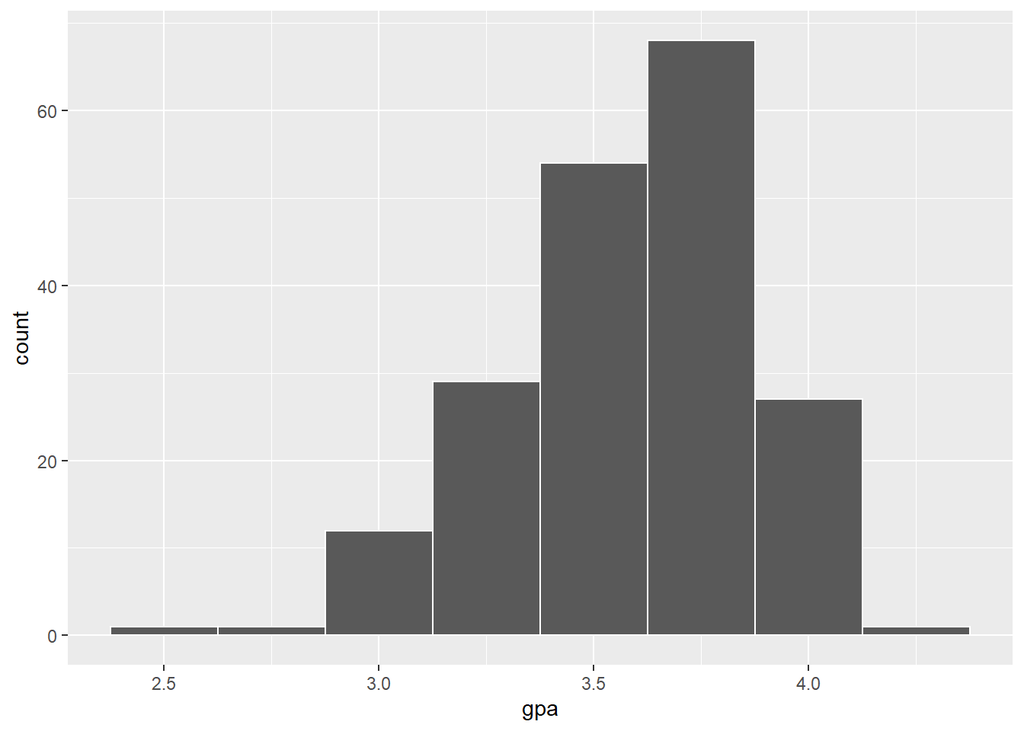

```r
ggplot(data = gpa_study_hours,
       aes(x = gpa))+
  geom_histogram(color = "White", binwidth = 0.25)
```

It would definitely be helpful to add a title and clean up the labels a bit. Using the ‘Help’ tab in the Directory pane, look up our dataset, *gpa_study_hours*, and read the description. We’ll use this to write our labels.

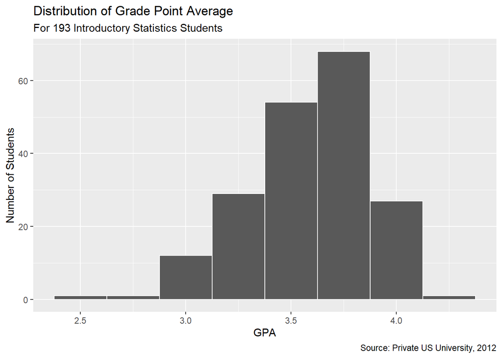

```r
ggplot(data = gpa_study_hours,
       aes(x = gpa))+
  geom_histogram(color = "White", binwidth = 0.25)+
  labs( #the labs() function allows us to add labels to our graph
    title = "Distribution of Grade Point Average",
    subtitle = "For 193 Introductory Statistics Students",
    x = "GPA",
    y = "Number of Students",
    caption = "Source: Private US University, 2012"
  )
```

For our next step, we’ll add a little flair. We’ll use some styles or “themes” from the *ggthemes* package. Use the ‘Packages’ tab in the Directory pane to look up *ggthemes* and take a look at some of our options. Note: In part II of the lab we will create more custom styles. You can think of part I (this lab) as using a cookie recipe someone else made. We’ll eat the cookie, see if we like it, and change what we don’t.

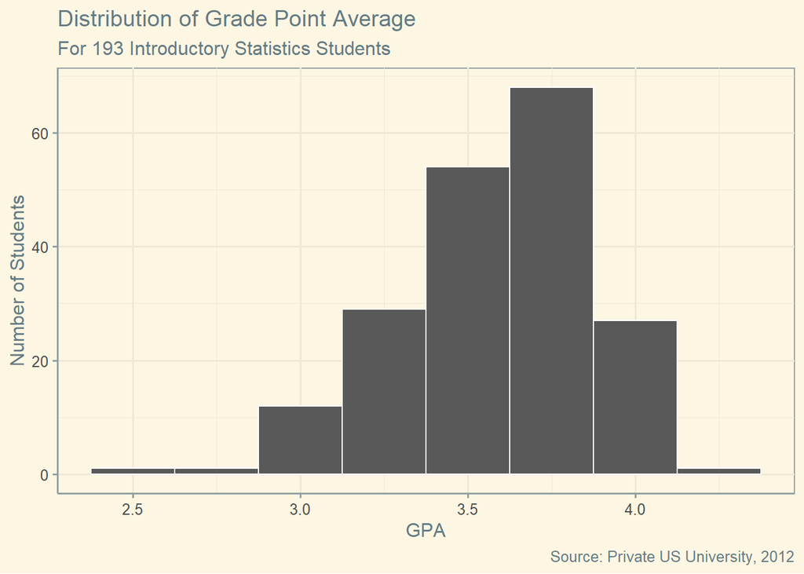

```r
ggplot(data = gpa_study_hours,
       aes(x = gpa))+
  geom_histogram(color = "White", binwidth = 0.25)+
  labs( #the labs() function allows us to add labels to our graph
    title = "Distribution of Grade Point Average",
    subtitle = "For 193 Introductory Statistics Students",
    x = "GPA",
    y = "Number of Students",
    caption = "Source: Private US University, 2012"
  )+
  theme_solarized()
```

I like this theme, but the gray bars seem out of place. I’ll change the recipe a bit.

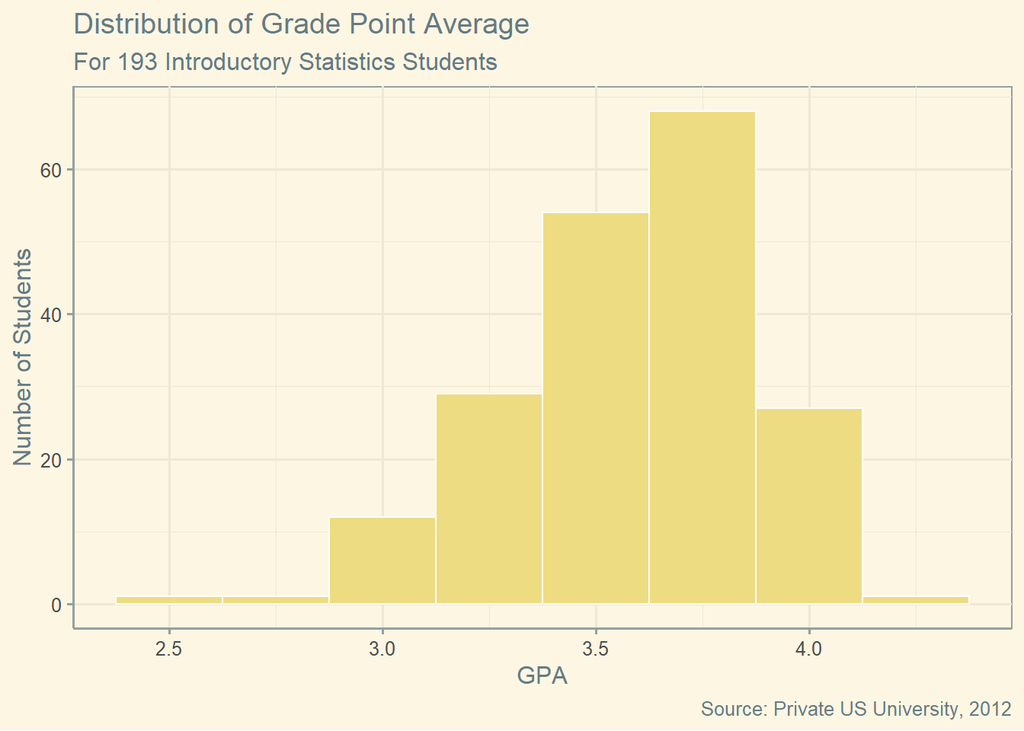

```r
ggplot(data = gpa_study_hours,
       aes(x = gpa))+
  geom_histogram(fill = "lightgoldenrod2",
                 color = "White",
                 binwidth = 0.25)+
  labs( #the labs() function allows us to add labels to our graph
    title = "Distribution of Grade Point Average",
    subtitle = "For 193 Introductory Statistics Students",
    x = "GPA",
    y = "Number of Students",
    caption = "Source: Private US University, 2012"
  )+
  theme_solarized()
```

That looks much better. To change the color of the bars, I added the *fill* argument to the geom_histogram() function. Here is a list of [colors](http://www.stat.columbia.edu/~tzheng/files/Rcolor.pdf).